# Dropping Intensity Predictors

Mike Mahoney true  
2020-12-29

## Evaluation Results

Last iteration of these models: [2020-12-29](https://docs.google.com/document/d/1kW1AQbGONCx-9_TmQolxY59zUZ14Ha3i0w7YfvXG6Dk/edit?usp=sharing)

### Change Summary

- Dropped intensity predictors
  - [Predictor definitions](https://docs.google.com/spreadsheets/d/1QWnuk98n2uGUXERl6Cj3Woneq6h_BXeOMFBzWgSK6Wg/edit?usp=sharing)
- RMSE-weighted ensemble is now correctly weighted by RMSE
  - Prior versions used MSE accidentally
  - Insignificant impact to RMSE, R2, but feels clearer to use RMSE for everything

|  | RF (ranger) | GBM (LightGBM) | SVM (kernlab) | Ensemble (model weighted) | Ensemble (RMSE weighted) |
| --- | --- | --- | --- | --- | --- |
| RMSE | 38.088 | 34.715 | 36.628 | 35.545 | 35.820 |
| R2 | 0.732 | 0.775 | 0.752 | 0.764 | 0.763 |

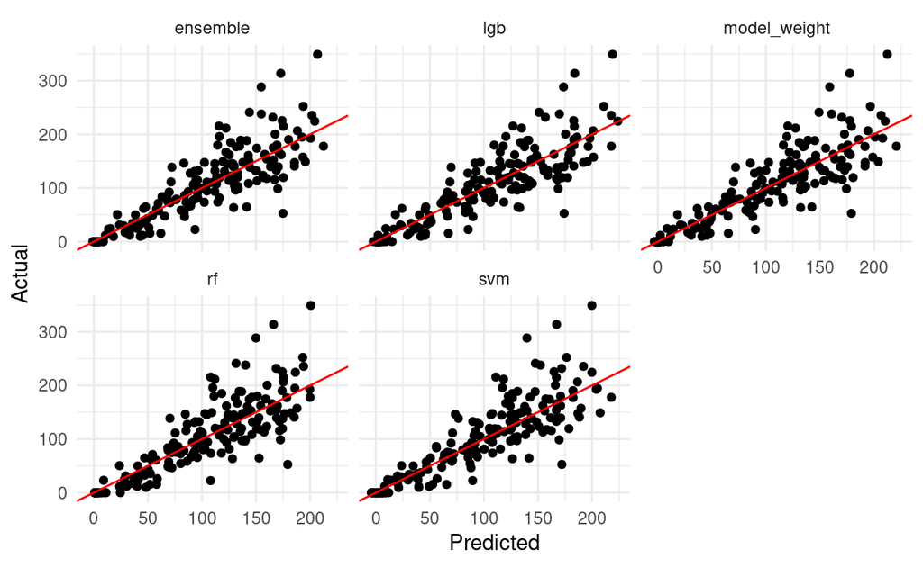

## Validation Results

| RMSE | Min | Median | Max |
| --- | --- | --- | --- |
| Rf | 34.382 | 39.488 | 47.609 |
| Lgb | 30.983 | 38.601 | 46.882 |
| Svm | 32.948 | 38.896 | 45.865 |
| Ensemble | 31.899 | 38.401 | 46.186 |

“Ensemble” here refers to the RMSE-weighted ensemble; the linear model ensemble is trained using the predictions from the validation stage (so doesn’t have any “test” data until we do the final evaluation).

| R2 | Min | Median | Max |
| --- | --- | --- | --- |
| Rf | 0.587 | 0.699 | 0.780 |
| Lgb | 0.593 | 0.710 | 0.806 |
| Svm | 0.609 | 0.704 | 0.779 |
| Ensemble | 0.610 | 0.715 | 0.796 |

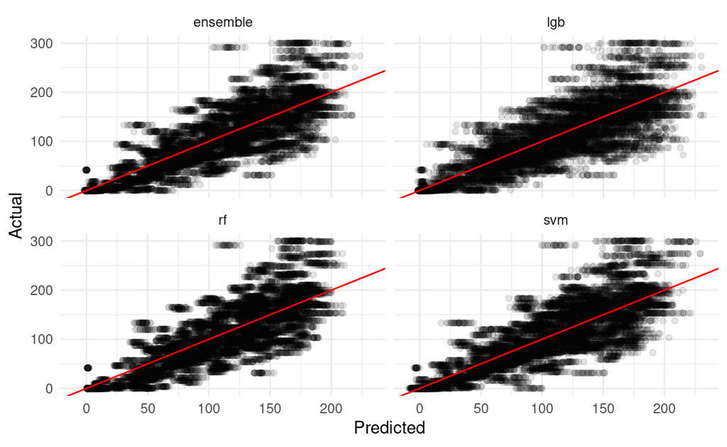

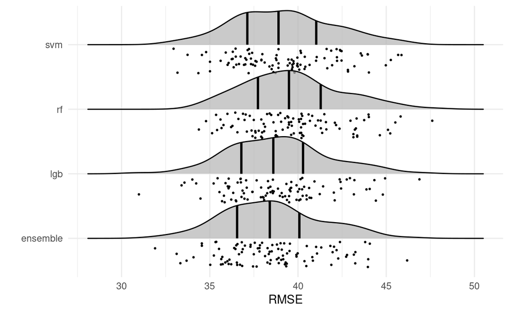

## Metadata

### Ensembles

- RMSE-weighted model weights:

```
       rf       lgb       svm
0.2996003 0.3553630 0.3450368
```

- Linear model weights:

```
Call:
lm(formula = agb_mgha ~ rf_pred * lgb_pred * svm_pred, data = pred_values)

Residuals:
     Min       1Q   Median       3Q      Max
-123.825  -21.383   -1.641   18.175  187.820

Coefficients:
                            Estimate Std. Error t value Pr(>|t|)
(Intercept)               -1.897e+00  1.039e+00  -1.827  0.06777 .
rf_pred                    1.515e-02  7.889e-02   0.192  0.84776
lgb_pred                   8.024e-01  9.097e-02   8.820  < 2e-16 ***
svm_pred                   2.093e-01  8.618e-02   2.428  0.01518 *
rf_pred:lgb_pred          -1.470e-03  7.050e-04  -2.085  0.03707 *
rf_pred:svm_pred           2.626e-03  6.789e-04   3.868  0.00011 ***
lgb_pred:svm_pred         -1.182e-03  7.558e-04  -1.564  0.11793
rf_pred:lgb_pred:svm_pred  5.231e-07  2.223e-06   0.235  0.81395
---
Signif. codes:  0 '***' 0.001 '**' 0.01 '*' 0.05 '.' 0.1 ' ' 1

Residual standard error: 38.47 on 12992 degrees of freedom
Multiple R-squared:  0.7125,    Adjusted R-squared:  0.7123
F-statistic:  4599 on 7 and 12992 DF,  p-value: < 2.2e-16
```

### $n$ and $p$

- 624 observations
  - 434 training
  - 190 testing
- 57 predictors
  - X, n, zmean, zmean_c, max, quad_mean, quad_mean_c, cv, cv_c, z_kurt, z_skew, L2, L3, L4, L_cv, L_skew, L_kurt, h10, h20, h30, h40, h50, h60, h70, h80, h90, h95, h99, hvol, cancov, rpc1, d10, d20, d30, d40, d50, d60, d70, d80, d90, stems, ca_max, ca_mean, ca_min, ca25, ca50, ca75, ca90, ca95, precip, tmin, tmax, twi, slope, aspect, elev, fold_index

### Component Models

```
$num.trees
[1] 300

$mtry
[1] 2

$min.node.size
[1] 5

$replace
[1] FALSE

$splitrule
[1] "variance"

$sample.fraction
[1] 0.2

$formula
agb_mgha ~ .
```

```
$learning_rate
[1] 0.1

$nrounds
[1] 50

$num_leaves
[1] 5

$extra_trees
[1] FALSE

$min_data_in_bin
[1] 13

$bagging_fraction
[1] 0.3

$feature_fraction
[1] 0.8

$lambda_l1
[1] 9

$lambda_l2
[1] 9

$force_col_wise
[1] TRUE
```

```
$x
agb_mgha ~ .

$kernel
[1] "laplacedot"

$type
[1] "eps-bsvr"

$kpar
$kpar$sigma
[1] 0.015625


$C
[1] 4

$epsilon
[1] 0.0625
```